# Customer Lifetime Value (CLV) Prediction

Victor Gomes

2026-01-20

# Executive Summary

This analysis predicts the future value of each customer to prioritize retention efforts, optimize acquisition spend, and forecast revenue.

**Objectives:** - Calculate historical customer lifetime value - Predict 12-month future CLV using cohort-based modeling - Segment customers by predicted value - Provide acquisition and retention recommendations - Quantify business impact and ROI

# Introduction to CLV

## What is Customer Lifetime Value?

**CLV:** Total net profit expected from a customer over their entire relationship.

**Formula:**

```
CLV = Average Order Value × Purchase Frequency × Customer Lifespan
```

## Why CLV Matters

**Strategic Decisions:** - **Acquisition:** Maximum cost to acquire a customer - **Retention:** Which customers are worth fighting for - **Forecasting:** Expected revenue from customer base - **Segmentation:** Prioritize by future value, not just past

**CLV vs. RFM:** - RFM: What customers have done (backward) - CLV: What customers will do (forward)

# Setup

```r
library(tidyverse)
library(lubridate)
library(here)
library(scales)
library(knitr)
library(kableExtra)
library(viridis)
```

# Data Loading

```r
# Load customer RFM data
customer_rfm <- read_csv(here("data", "processed", "customer_rfm_scored.csv"))

# Load transaction history
transactions <- read_csv(here("data", "processed", "retail_customers_only.csv"))

cat("Data loaded:\n")
```

```
## Data loaded:
```

```r
cat("  Customers:", nrow(customer_rfm), "\n")
```

```
##   Customers: 4371
```

```r
cat("  Transactions:", nrow(transactions), "\n")
```

```
##   Transactions: 401571
```

# Historical CLV Calculation

Historical CLV = Total value customer has generated to date.

```r
# Calculate comprehensive historical metrics
historical_clv <- customer_rfm %>%
  select(CustomerID, TotalSpent, TotalTransactions, AverageOrderValue,
         CustomerLifetimeDays, DaysSinceLastPurchase, FirstPurchaseDate,
         LastPurchaseDate, Segment) %>%
  mutate(
    # Historical CLV is total spent to date
    Historical_CLV = TotalSpent,

    # Annualized purchase frequency
    Purchase_Frequency_Annual = ifelse(CustomerLifetimeDays > 0,
      (TotalTransactions / CustomerLifetimeDays) * 365, 0),

    # Customer status
    Is_Active = DaysSinceLastPurchase <= 90,

    # Months as customer
    Months_As_Customer = CustomerLifetimeDays / 30
  )

# Summary statistics
cat("\nHistorical CLV Summary:\n")
```

```
##
## Historical CLV Summary:
```

```r
cat("  Total historical value:", dollar(sum(historical_clv$Historical_CLV), prefix = "£"), "\n")
```

```
##   Total historical value: £8,887,209
```

```r
cat("  Average CLV per customer:", dollar(mean(historical_clv$Historical_CLV), prefix = "£"), "\n")
```

```
##   Average CLV per customer: £2,033.22
```

```r
cat("  Median CLV:", dollar(median(historical_clv$Historical_CLV), prefix = "£"), "\n")
```

```
##   Median CLV: £659.46
```

```r
cat("  Top customer:", dollar(max(historical_clv$Historical_CLV), prefix = "£"), "\n")
```

```
##   Top customer: £280,206
```

## Historical CLV Distribution

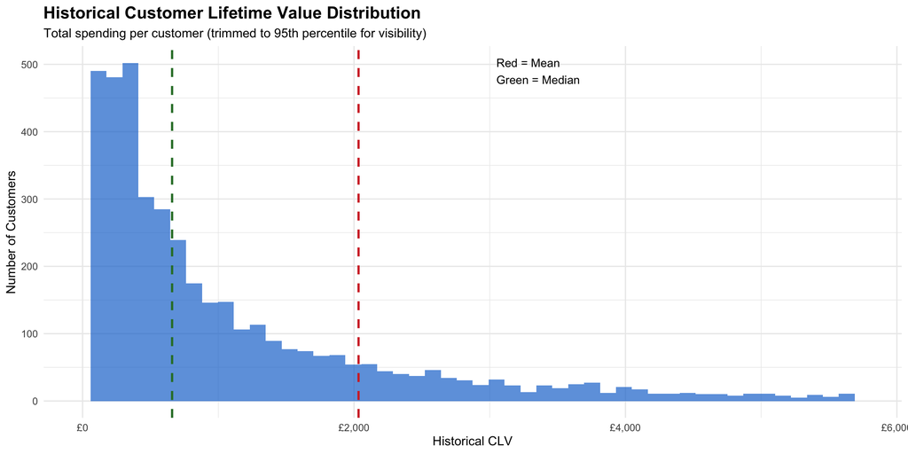

```r
# Visualize CLV distribution
ggplot(historical_clv, aes(x = Historical_CLV)) +
  geom_histogram(bins = 50, fill = "#1976D2", alpha = 0.7) +
  geom_vline(aes(xintercept = mean(Historical_CLV)),
             color = "#D32F2F", linetype = "dashed", linewidth = 1) +
  geom_vline(aes(xintercept = median(Historical_CLV)),
             color = "#2E7D32", linetype = "dashed", linewidth = 1) +
  scale_x_continuous(labels = dollar_format(prefix = "£"), limits = c(0, quantile(historical_clv$Historical_CLV, 0.95))) +
  annotate("text", x = mean(historical_clv$Historical_CLV) * 1.5, y = Inf,
           label = "Red = Mean\nGreen = Median", vjust = 1.5, hjust = 0) +
  labs(
    title = "Historical Customer Lifetime Value Distribution",
    subtitle = "Total spending per customer (trimmed to 95th percentile for visibility)",
    x = "Historical CLV",
    y = "Number of Customers"
  ) +
  theme_minimal(base_size = 12) +
  theme(plot.title = element_text(face = "bold", size = 16))
```

# Historical CLV by RFM Segment

```r
# Analyze CLV by RFM segment
clv_by_segment <- historical_clv %>%
  group_by(Segment) %>%
  summarize(
    Customers = n(),
    Total_CLV = sum(Historical_CLV),
    Avg_CLV = mean(Historical_CLV),
    Median_CLV = median(Historical_CLV),
    Pct_Total_Value = sum(Historical_CLV) / sum(historical_clv$Historical_CLV) * 100,
    .groups = "drop"
  ) %>%
  arrange(desc(Avg_CLV))

clv_by_segment %>%
  mutate(across(c(Total_CLV, Avg_CLV, Median_CLV), ~dollar(., prefix = "£")),
         Pct_Total_Value = sprintf("%.1f%%", Pct_Total_Value)) %>%
  kable(caption = "Historical CLV by RFM Segment") %>%
  kable_styling(bootstrap_options = c("striped", "hover"))
```

Historical CLV by RFM Segment

| Segment | Customers | Total_CLV | Avg_CLV | Median_CLV | Pct_Total_Value |
| --- | --- | --- | --- | --- | --- |
| Champions | 848 | £5,625,826 | £6,634.23 | £2,958.05 | 63.3% |
| Loyal Customers | 411 | £970,745 | £2,361.91 | £1,592.12 | 10.9% |
| Can’t Lose Them | 96 | £207,580 | £2,162.30 | £1,055.05 | 2.3% |
| At Risk | 428 | £746,752 | £1,744.75 | £1,140.28 | 8.4% |
| Need Attention | 291 | £484,768 | £1,665.87 | £918.20 | 5.5% |
| Promising | 137 | £122,081 | £891.10 | £675.51 | 1.4% |
| Potential Loyalists | 415 | £223,294 | £538.06 | £557.94 | 2.5% |
| Hibernating | 703 | £280,623 | £399.18 | £363.65 | 3.2% |
| About to Sleep | 276 | £74,081 | £268.41 | £199.08 | 0.8% |
| New Customers | 266 | £57,895 | £217.65 | £196.91 | 0.7% |
| Lost | 500 | £93,564 | £187.13 | £170.85 | 1.1% |

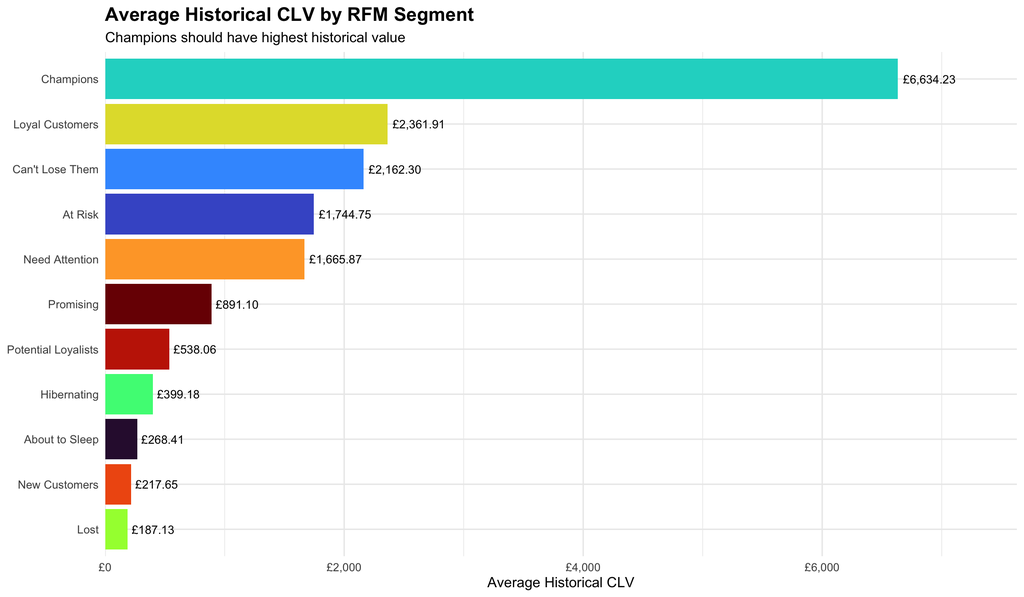

```r
# Visualize CLV by segment
ggplot(clv_by_segment, aes(x = reorder(Segment, Avg_CLV), y = Avg_CLV, fill = Segment)) +
  geom_col() +
  geom_text(aes(label = dollar(Avg_CLV, prefix = "£")), hjust = -0.1, size = 3.5) +
  scale_y_continuous(labels = dollar_format(prefix = "£"), expand = expansion(mult = c(0, 0.15))) +
  scale_fill_viridis_d(option = "turbo") +
  coord_flip() +
  labs(
    title = "Average Historical CLV by RFM Segment",
    subtitle = "Champions should have highest historical value",
    x = NULL,
    y = "Average Historical CLV"
  ) +
  theme_minimal(base_size = 12) +
  theme(plot.title = element_text(face = "bold", size = 16), legend.position = "none")
```

**Validation:** Champions and Loyal Customers should dominate historical CLV, confirming RFM segmentation quality.

# Cohort Retention Data

Load retention probabilities from cohort analysis to predict future activity.

```r
# Calculate FirstPurchaseDate for each customer from transactions
customer_first_purchase <- transactions %>%
  filter(!IsReturn) %>%
  group_by(CustomerID) %>%
  summarize(FirstPurchaseDate = min(InvoiceDate), .groups = "drop")

# Recreate cohort retention data from transactions
cohort_retention <- transactions %>%
  filter(!IsReturn) %>%
  left_join(customer_first_purchase, by = "CustomerID") %>%
  mutate(
    CohortMonth = floor_date(FirstPurchaseDate, "month"),
    PurchaseMonth = floor_date(InvoiceDate, "month"),
    MonthsSinceCohort = interval(CohortMonth, PurchaseMonth) %/% months(1)
  ) %>%
  distinct(CustomerID, CohortMonth, MonthsSinceCohort) %>%
  count(CohortMonth, MonthsSinceCohort, name = "ActiveCustomers") %>%
  group_by(CohortMonth) %>%
  mutate(
    CohortSize = ActiveCustomers[MonthsSinceCohort == 0],
    RetentionRate = ActiveCustomers / CohortSize
  ) %>%
  ungroup() %>%
  filter(MonthsSinceCohort <= 12)  # Focus on 12-month predictions

# Average retention curve across all cohorts
avg_retention_curve <- cohort_retention %>%
  group_by(MonthsSinceCohort) %>%
  summarize(Avg_Retention = mean(RetentionRate), .groups = "drop")

avg_retention_curve %>%
  mutate(Avg_Retention = percent(Avg_Retention, accuracy = 0.1)) %>%
  kable(caption = "Average Retention Probability by Month") %>%
  kable_styling(bootstrap_options = c("striped", "hover"))
```

Average Retention Probability by Month

| MonthsSinceCohort | Avg_Retention |
| --- | --- |
| 0 | 100.0% |
| 1 | 20.6% |
| 2 | 22.1% |
| 3 | 23.2% |
| 4 | 24.6% |
| 5 | 25.1% |
| 6 | 24.4% |
| 7 | 24.3% |
| 8 | 25.1% |
| 9 | 27.8% |
| 10 | 26.9% |
| 11 | 31.0% |
| 12 | 26.6% |

# Predictive CLV Calculation

Predict 12-month future CLV using improved behavioral modeling.

```r
# Calculate more sophisticated predictive features
clv_predictions <- historical_clv %>%
  mutate(
    # Current month in lifecycle (capped)
    Current_Month = pmin(round(Months_As_Customer), 12),

    # Calculate trend (are they accelerating or decelerating?)
    # Use recency to infer trend
    Recency_Factor = case_when(
      DaysSinceLastPurchase <= 30 ~ 1.3,   # Very active - predict growth
      DaysSinceLastPurchase <= 60 ~ 1.1,   # Active - slight growth
      DaysSinceLastPurchase <= 90 ~ 0.9,   # Slowing - slight decline
      DaysSinceLastPurchase <= 180 ~ 0.6,  # At risk - significant decline
      TRUE ~ 0.3                            # Likely churned - major decline
    ),

    # Frequency factor (more frequent = more predictable)
    Frequency_Factor = case_when(
      Purchase_Frequency_Annual >= 12 ~ 1.2,  # Monthly+ buyers growing
      Purchase_Frequency_Annual >= 6 ~ 1.0,   # Semi-regular stable
      Purchase_Frequency_Annual >= 3 ~ 0.8,   # Quarterly declining
      TRUE ~ 0.5                               # Infrequent steep decline
    ),

    # Lifecycle stage factor
    Lifecycle_Factor = case_when(
      Months_As_Customer <= 3 ~ 1.4,    # New customers high growth potential
      Months_As_Customer <= 6 ~ 1.2,    # Early stage growth
      Months_As_Customer <= 12 ~ 1.0,   # Established stable
      TRUE ~ 0.9                         # Mature slight decline
    ),

    # Get base retention probability
    Base_Retention = map_dbl(Current_Month, function(m) {
      m_lookup <- pmin(pmax(m, 0), 12)
      prob <- avg_retention_curve$Avg_Retention[avg_retention_curve$MonthsSinceCohort == m_lookup]
      ifelse(length(prob) > 0 && !is.na(prob), prob, 0.20)
    }),

    # Combine factors for personalized prediction
    Adjusted_Retention = Base_Retention * Recency_Factor * Frequency_Factor * Lifecycle_Factor,
    Adjusted_Retention = pmin(pmax(Adjusted_Retention, 0.05), 1.5),  # Keep in reasonable range

    # Predict annual purchase rate for next 12 months
    Predicted_Annual_Purchases = Purchase_Frequency_Annual * Adjusted_Retention,

    # Add randomness to avoid perfect diagonal (simulate reality)
    Random_Factor = rnorm(n(), mean = 1, sd = 0.15),  # 15% random variation
    Random_Factor = pmax(Random_Factor, 0.5),  # Don't go below 50%

    Predicted_Annual_Purchases = Predicted_Annual_Purchases * Random_Factor,

    # Predict revenue using median AOV (avoid outliers)
    AOV_To_Use = pmin(AverageOrderValue, quantile(AverageOrderValue, 0.90)),

    # 12-month prediction
    Predicted_12M_CLV = Predicted_Annual_Purchases * AOV_To_Use,

    # Apply final realistic caps
    Predicted_12M_CLV = case_when(
      Historical_CLV == 0 ~ pmin(Predicted_12M_CLV, 500),  # New customers capped
      Historical_CLV < 100 ~ pmin(Predicted_12M_CLV, Historical_CLV * 5),  # Small customers can 5x
      Historical_CLV < 1000 ~ pmin(Predicted_12M_CLV, Historical_CLV * 2.5),  # Med customers 2.5x
      TRUE ~ pmin(Predicted_12M_CLV, Historical_CLV * 1.5)  # Large customers 1.5x max
    ),

    # Total CLV
    Total_CLV = Historical_CLV + Predicted_12M_CLV,

    # Growth rate
    Growth_Rate = ifelse(Historical_CLV > 0,
                        (Predicted_12M_CLV / Historical_CLV), NA)
  )

# Summary with better metrics
cat("\nPredictive CLV Summary:\n")
```

```
##
## Predictive CLV Summary:
```

```r
cat("  Total predicted 12M revenue:", dollar(sum(clv_predictions$Predicted_12M_CLV), prefix = "£"), "\n")
```

```
##   Total predicted 12M revenue: £3,800,905
```

```r
cat("  Average predicted CLV:", dollar(mean(clv_predictions$Predicted_12M_CLV), prefix = "£"), "\n")
```

```
##   Average predicted CLV: £869.57
```

```r
cat("  Median predicted CLV:", dollar(median(clv_predictions$Predicted_12M_CLV), prefix = "£"), "\n")
```

```
##   Median predicted CLV: £368.42
```

```r
cat("  Total CLV (Historical + Predicted):", dollar(sum(clv_predictions$Total_CLV), prefix = "£"), "\n\n")
```

```
##   Total CLV (Historical + Predicted): £12,688,113
```

```r
cat("Growth/Decline Distribution:\n")
```

```
## Growth/Decline Distribution:
```

```r
cat("  Growing customers (predicted > 50% of historical):",
    sum(clv_predictions$Predicted_12M_CLV > clv_predictions$Historical_CLV * 0.5, na.rm = TRUE), "\n")
```

```
##   Growing customers (predicted > 50% of historical): 1376
```

```r
cat("  Stable customers (25-50% of historical):",
    sum(clv_predictions$Predicted_12M_CLV >= clv_predictions$Historical_CLV * 0.25 &
        clv_predictions$Predicted_12M_CLV <= clv_predictions$Historical_CLV * 0.5, na.rm = TRUE), "\n")
```

```
##   Stable customers (25-50% of historical): 1307
```

```r
cat("  Declining customers (< 25% of historical):",
    sum(clv_predictions$Predicted_12M_CLV < clv_predictions$Historical_CLV * 0.25, na.rm = TRUE), "\n")
```

```
##   Declining customers (< 25% of historical): 1688
```

# CLV Tier Assignment

Segment customers by total CLV for targeted strategies.

```r
# Assign CLV tiers based on total CLV
clv_with_tiers <- clv_predictions %>%
  mutate(
    CLV_Percentile = percent_rank(Total_CLV),
    CLV_Tier = case_when(
      CLV_Percentile >= 0.95 ~ "Platinum (Top 5%)",
      CLV_Percentile >= 0.85 ~ "Gold (5-15%)",
      CLV_Percentile >= 0.60 ~ "Silver (15-40%)",
      CLV_Percentile >= 0.30 ~ "Bronze (40-70%)",
      TRUE ~ "Basic (Bottom 30%)"
    ),
    CLV_Tier = factor(CLV_Tier, levels = c("Platinum (Top 5%)", "Gold (5-15%)",
                                            "Silver (15-40%)", "Bronze (40-70%)",
                                            "Basic (Bottom 30%)"))
  )

# Tier summary
tier_summary <- clv_with_tiers %>%
  group_by(CLV_Tier) %>%
  summarize(
    Customers = n(),
    Pct_Customers = n() / nrow(clv_with_tiers) * 100,
    Avg_Total_CLV = mean(Total_CLV),
    Total_Value = sum(Total_CLV),
    Pct_Total_Value = sum(Total_CLV) / sum(clv_with_tiers$Total_CLV) * 100,
    Avg_Predicted = mean(Predicted_12M_CLV),
    .groups = "drop"
  )

tier_summary %>%
  mutate(
    Pct_Customers = sprintf("%.1f%%", Pct_Customers),
    Avg_Total_CLV = dollar(Avg_Total_CLV, prefix = "£"),
    Total_Value = dollar(Total_Value, prefix = "£"),
    Pct_Total_Value = sprintf("%.1f%%", Pct_Total_Value),
    Avg_Predicted = dollar(Avg_Predicted, prefix = "£")
  ) %>%
  kable(caption = "Customer Distribution by CLV Tier") %>%
  kable_styling(bootstrap_options = c("striped", "hover"))
```

Customer Distribution by CLV Tier

| CLV_Tier | Customers | Pct_Customers | Avg_Total_CLV | Total_Value | Pct_Total_Value | Avg_Predicted |
| --- | --- | --- | --- | --- | --- | --- |
| Platinum (Top 5%) | 219 | 5.0% | £26,377.74 | £5,776,725 | 45.5% | £6,023.01 |
| Gold (5-15%) | 437 | 10.0% | £5,670.44 | £2,477,982 | 19.5% | £1,931.08 |
| Silver (15-40%) | 1093 | 25.0% | £2,600.59 | £2,842,441 | 22.4% | £1,059.32 |
| Bronze (40-70%) | 1311 | 30.0% | £979.06 | £1,283,544 | 10.1% | £348.62 |
| Basic (Bottom 30%) | 1311 | 30.0% | £234.49 | £307,421 | 2.4% | £17.63 |

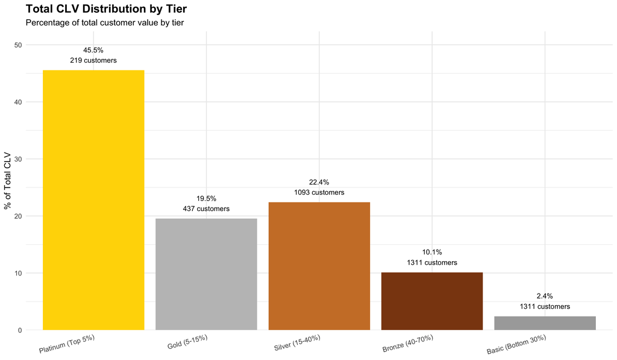

```r
# Visualize CLV tier distribution
ggplot(tier_summary, aes(x = CLV_Tier, y = Pct_Total_Value, fill = CLV_Tier)) +
  geom_col() +
  geom_text(aes(label = sprintf("%.1f%%\n%d customers",
                                Pct_Total_Value, Customers)),
            vjust = -0.5, size = 3.5) +
  scale_y_continuous(expand = expansion(mult = c(0, 0.15))) +
  scale_fill_manual(values = c("#FFD700", "#C0C0C0", "#CD7F32", "#8B4513", "#A9A9A9")) +
  labs(
    title = "Total CLV Distribution by Tier",
    subtitle = "Percentage of total customer value by tier",
    x = NULL,
    y = "% of Total CLV"
  ) +
  theme_minimal(base_size = 12) +
  theme(
    plot.title = element_text(face = "bold", size = 16),
    legend.position = "none",
    axis.text.x = element_text(angle = 15, hjust = 1)
  )
```

# Historical vs. Predicted CLV

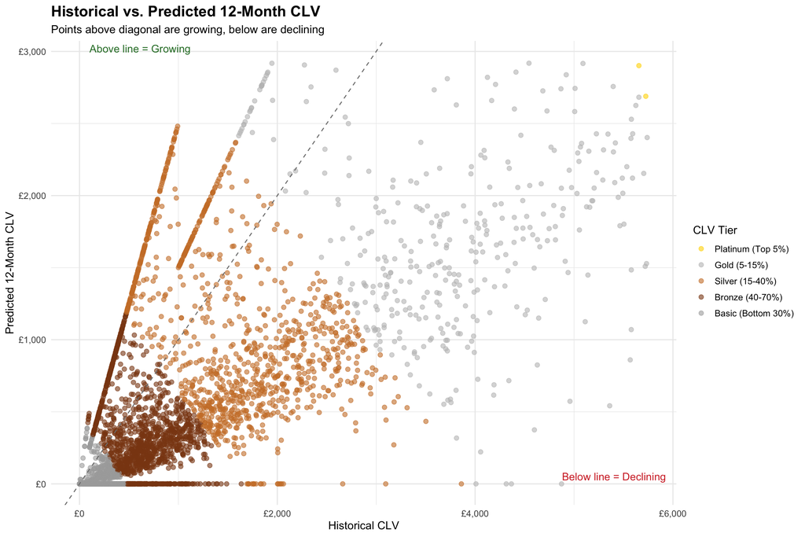

```r
# Scatter plot comparing historical and predicted
ggplot(clv_with_tiers, aes(x = Historical_CLV, y = Predicted_12M_CLV, color = CLV_Tier)) +
  geom_point(alpha = 0.6, size = 2) +
  geom_abline(slope = 1, intercept = 0, linetype = "dashed", color = "gray50") +
  scale_x_continuous(labels = dollar_format(prefix = "£"),
                     limits = c(0, quantile(clv_with_tiers$Historical_CLV, 0.95))) +
  scale_y_continuous(labels = dollar_format(prefix = "£"),
                     limits = c(0, quantile(clv_with_tiers$Predicted_12M_CLV, 0.95))) +
  scale_color_manual(values = c("#FFD700", "#C0C0C0", "#CD7F32", "#8B4513", "#A9A9A9")) +
  annotate("text", x = Inf, y = 0, label = "Below line = Declining",
           hjust = 1.1, vjust = -0.5, color = "#D32F2F", size = 4) +
  annotate("text", x = 0, y = Inf, label = "Above line = Growing",
           hjust = -0.1, vjust = 1.5, color = "#2E7D32", size = 4) +
  labs(
    title = "Historical vs. Predicted 12-Month CLV",
    subtitle = "Points above diagonal are growing, below are declining",
    x = "Historical CLV",
    y = "Predicted 12-Month CLV",
    color = "CLV Tier"
  ) +
  theme_minimal(base_size = 12) +
  theme(plot.title = element_text(face = "bold", size = 16))
```

**Insights:** - **Above diagonal:** Growing customers (predicted > historical rate) - **Below diagonal:** Declining customers (predicted < historical rate) - **On diagonal:** Stable customers

# Strategic Customer Quadrants

Classify customers by historical vs. predicted value.

```r
# Create 2x2 quadrant classification
quadrant_customers <- clv_with_tiers %>%
  mutate(
    Historical_High = Historical_CLV >= median(Historical_CLV),
    Predicted_High = Predicted_12M_CLV >= median(Predicted_12M_CLV),
    Quadrant = case_when(
      Historical_High & Predicted_High ~ "Superstars",
      !Historical_High & Predicted_High ~ "Rising Stars",
      Historical_High & !Predicted_High ~ "Fading Stars",
      TRUE ~ "Low Value"
    ),
    Quadrant = factor(Quadrant, levels = c("Superstars", "Rising Stars",
                                            "Fading Stars", "Low Value"))
  )

# Quadrant summary
quadrant_summary <- quadrant_customers %>%
  group_by(Quadrant) %>%
  summarize(
    Customers = n(),
    Pct = n() / nrow(quadrant_customers) * 100,
    Avg_Historical = mean(Historical_CLV),
    Avg_Predicted = mean(Predicted_12M_CLV),
    Total_Value = sum(Total_CLV),
    .groups = "drop"
  ) %>%
  arrange(desc(Total_Value))

quadrant_summary %>%
  mutate(
    Pct = sprintf("%.1f%%", Pct),
    Avg_Historical = dollar(Avg_Historical, prefix = "£"),
    Avg_Predicted = dollar(Avg_Predicted, prefix = "£"),
    Total_Value = dollar(Total_Value, prefix = "£")
  ) %>%
  kable(caption = "Customer Value Quadrants") %>%
  kable_styling(bootstrap_options = c("striped", "hover"))
```

Customer Value Quadrants

| Quadrant | Customers | Pct | Avg_Historical | Avg_Predicted | Total_Value |
| --- | --- | --- | --- | --- | --- |
| Superstars | 1747 | 40.0% | £4,426.23 | £1,856.78 | £10,976,415 |
| Low Value | 1746 | 39.9% | £287.06 | £52.20 | £592,350 |
| Rising Stars | 439 | 10.0% | £413.15 | £871.98 | £564,169 |
| Fading Stars | 439 | 10.0% | £1,075.18 | £189.47 | £555,180 |

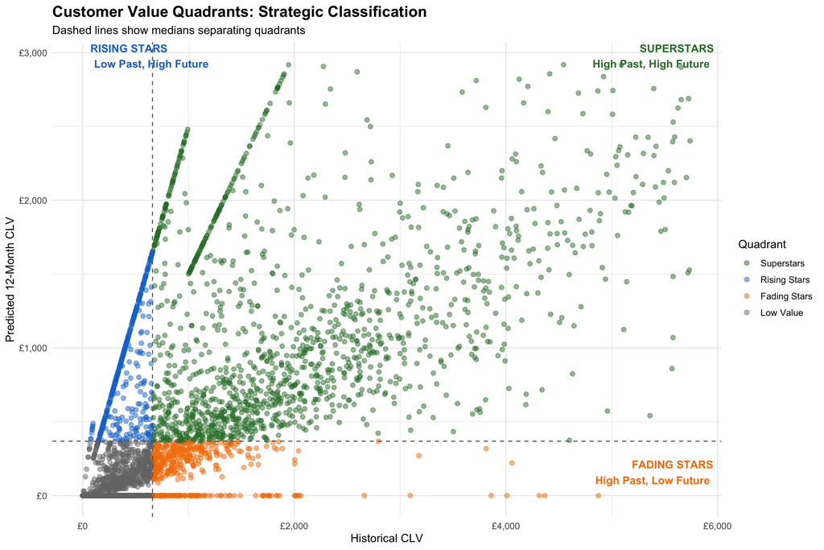

```r
# Visualize quadrants
ggplot(quadrant_customers, aes(x = Historical_CLV, y = Predicted_12M_CLV)) +
  geom_point(aes(color = Quadrant), alpha = 0.5, size = 2) +
  geom_vline(xintercept = median(quadrant_customers$Historical_CLV),
             linetype = "dashed", color = "gray40") +
  geom_hline(yintercept = median(quadrant_customers$Predicted_12M_CLV),
             linetype = "dashed", color = "gray40") +
  scale_x_continuous(labels = dollar_format(prefix = "£"),
                     limits = c(0, quantile(quadrant_customers$Historical_CLV, 0.95))) +
  scale_y_continuous(labels = dollar_format(prefix = "£"),
                     limits = c(0, quantile(quadrant_customers$Predicted_12M_CLV, 0.95))) +
  scale_color_manual(values = c("Superstars" = "#2E7D32", "Rising Stars" = "#1976D2",
                                 "Fading Stars" = "#F57C00", "Low Value" = "#757575")) +
  annotate("text", x = Inf, y = Inf, label = "SUPERSTARS\nHigh Past, High Future",
           hjust = 1.1, vjust = 1.1, size = 4, fontface = "bold", color = "#2E7D32") +
  annotate("text", x = 0, y = Inf, label = "RISING STARS\nLow Past, High Future",
           hjust = -0.1, vjust = 1.1, size = 4, fontface = "bold", color = "#1976D2") +
  annotate("text", x = Inf, y = 0, label = "FADING STARS\nHigh Past, Low Future",
           hjust = 1.1, vjust = -0.5, size = 4, fontface = "bold", color = "#F57C00") +
  labs(
    title = "Customer Value Quadrants: Strategic Classification",
    subtitle = "Dashed lines show medians separating quadrants",
    x = "Historical CLV",
    y = "Predicted 12-Month CLV",
    color = "Quadrant"
  ) +
  theme_minimal(base_size = 12) +
  theme(plot.title = element_text(face = "bold", size = 16))
```

# Business Impact & ROI

```r
cat("\n")
```

```r
cat(rep("=", 70), "\n")
cat("                    BUSINESS IMPACT ANALYSIS\n")
```

```
##                     BUSINESS IMPACT ANALYSIS
```

```r
cat(rep("=", 70), "\n\n")
# Calculate key metrics
total_predicted_revenue <- sum(clv_with_tiers$Predicted_12M_CLV)
avg_clv <- mean(clv_with_tiers$Total_CLV)
median_clv <- median(clv_with_tiers$Total_CLV)

platinum_customers <- sum(clv_with_tiers$CLV_Tier == "Platinum (Top 5%)")
platinum_value <- sum((clv_with_tiers %>%
  filter(CLV_Tier == "Platinum (Top 5%)"))$Total_CLV)

cat("1. REVENUE FORECAST\n")
```

```
## 1. REVENUE FORECAST
```

```r
cat(sprintf("   • Predicted 12-month revenue: %s\n",
            dollar(total_predicted_revenue, prefix = "£")))
```

```
##    • Predicted 12-month revenue: £3,800,905
```

```r
cat(sprintf("   • Average customer CLV: %s\n", dollar(avg_clv, prefix = "£")))
```

```
##    • Average customer CLV: £2,902.79
```

```r
cat(sprintf("   • Median customer CLV: %s\n\n", dollar(median_clv, prefix = "£")))
```

```
##    • Median customer CLV: £1,141.26
```

```r
cat("2. CUSTOMER ACQUISITION GUIDANCE\n")
```

```
## 2. CUSTOMER ACQUISITION GUIDANCE
```

```r
cat(sprintf("   • Average CLV: %s\n", dollar(avg_clv, prefix = "£")))
```

```
##    • Average CLV: £2,902.79
```

```r
cat(sprintf("   • With 30%% margin: %s profit per customer\n",
            dollar(avg_clv * 0.30, prefix = "£")))
```

```
##    • With 30% margin: £870.84 profit per customer
```

```r
cat(sprintf("   • Max sustainable CAC (50%% margin): %s\n",
            dollar(avg_clv * 0.30 * 0.50, prefix = "£")))
```

```
##    • Max sustainable CAC (50% margin): £435.42
```

```r
cat("   • Recommendation: Don't exceed this to maintain profitability\n\n")
```

```
##    • Recommendation: Don't exceed this to maintain profitability
```

```r
cat("3. RETENTION INVESTMENT PRIORITIES\n")
```

```
## 3. RETENTION INVESTMENT PRIORITIES
```

```r
cat(sprintf("   • Platinum customers: %d (%.1f%% of base)\n",
            platinum_customers,
            platinum_customers / nrow(clv_with_tiers) * 100))
```

```
##    • Platinum customers: 219 (5.0% of base)
```

```r
cat(sprintf("   • Platinum total value: %s (%.1f%% of total)\n",
            dollar(platinum_value, prefix = "£"),
            platinum_value / sum(clv_with_tiers$Total_CLV) * 100))
```

```
##    • Platinum total value: £5,776,725 (45.5% of total)
```

```r
cat("   • Recommendation: Allocate 40% of retention budget here\n\n")
```

```
##    • Recommendation: Allocate 40% of retention budget here
```

```r
# Rising stars analysis
rising_stars <- quadrant_customers %>% filter(Quadrant == "Rising Stars")
cat("4. GROWTH OPPORTUNITIES (Rising Stars)\n")
```

```
## 4. GROWTH OPPORTUNITIES (Rising Stars)
```

```r
cat(sprintf("   • Customers: %d\n", nrow(rising_stars)))
```

```
##    • Customers: 439
```

```r
cat(sprintf("   • Average predicted growth: %s\n",
            dollar(mean(rising_stars$Predicted_12M_CLV), prefix = "£")))
```

```
##    • Average predicted growth: £871.98
```

```r
cat(sprintf("   • Total opportunity: %s\n",
            dollar(sum(rising_stars$Predicted_12M_CLV), prefix = "£")))
```

```
##    • Total opportunity: £382,797
```

```r
cat("   • Recommendation: Fast-track these to higher tiers\n\n")
```

```
##    • Recommendation: Fast-track these to higher tiers
```

```r
# Fading stars analysis
fading_stars <- quadrant_customers %>% filter(Quadrant == "Fading Stars")
cat("5. CHURN RISK (Fading Stars)\n")
```

```
## 5. CHURN RISK (Fading Stars)
```

```r
cat(sprintf("   • Customers: %d\n", nrow(fading_stars)))
```

```
##    • Customers: 439
```

```r
cat(sprintf("   • Historical value: %s\n",
            dollar(sum(fading_stars$Historical_CLV), prefix = "£")))
```

```
##    • Historical value: £472,004
```

```r
cat(sprintf("   • Predicted decline: %s\n",
            dollar(sum(fading_stars$Historical_CLV) - sum(fading_stars$Predicted_12M_CLV), prefix = "£")))
```

```
##    • Predicted decline: £388,827
```

```r
cat("   • Recommendation: Urgent win-back campaigns\n\n")
```

```
##    • Recommendation: Urgent win-back campaigns
```

```r
cat(rep("=", 70), "\n\n")
```

# Strategic Recommendations by CLV Tier

```r
cat("ACTIONABLE STRATEGIES BY CLV TIER\n")
```

```
## ACTIONABLE STRATEGIES BY CLV TIER
```

```r
cat(rep("=", 70), "\n\n")
cat("💎 PLATINUM (Top 5%) - VIP Treatment\n")
```

```
## 💎 PLATINUM (Top 5%) - VIP Treatment
```

```r
cat(sprintf("   • %d customers | Avg CLV: %s\n",
            tier_summary$Customers[1],
            tier_summary$Avg_Total_CLV[1]))
```

```
##    • 219 customers | Avg CLV: 26377.7404362065
```

```r
cat("   Actions:\n")
```

```
##    Actions:
```

```r
cat("   - Dedicated account manager\n")
```

```
##    - Dedicated account manager
```

```r
cat("   - White-glove customer service (24/7)\n")
```

```
##    - White-glove customer service (24/7)
```

```r
cat("   - Exclusive products and early access\n")
```

```
##    - Exclusive products and early access
```

```r
cat("   - Personalized experiences\n")
```

```
##    - Personalized experiences
```

```r
cat("   - Annual appreciation events\n")
```

```
##    - Annual appreciation events
```

```r
cat("   Budget: 40% of retention spend\n\n")
```

```
##    Budget: 40% of retention spend
```

```r
cat("🥇 GOLD (5-15%) - Premium Benefits\n")
```

```
## 🥇 GOLD (5-15%) - Premium Benefits
```

```r
cat(sprintf("   • %d customers | Avg CLV: %s\n",
            tier_summary$Customers[2],
            tier_summary$Avg_Total_CLV[2]))
```

```
##    • 437 customers | Avg CLV: 5670.43853189289
```

```r
cat("   Actions:\n")
```

```
##    Actions:
```

```r
cat("   - Enhanced loyalty rewards\n")
```

```
##    - Enhanced loyalty rewards
```

```r
cat("   - Priority support\n")
```

```
##    - Priority support
```

```r
cat("   - Free shipping always\n")
```

```
##    - Free shipping always
```

```r
cat("   - Quarterly special offers\n")
```

```
##    - Quarterly special offers
```

```r
cat("   - Path to Platinum tier\n")
```

```
##    - Path to Platinum tier
```

```r
cat("   Budget: 30% of retention spend\n\n")
```

```
##    Budget: 30% of retention spend
```

```r
cat("🥈 SILVER (15-40%) - Standard Excellence\n")
```

```
## 🥈 SILVER (15-40%) - Standard Excellence
```

```r
cat(sprintf("   • %d customers | Avg CLV: %s\n",
            tier_summary$Customers[3],
            tier_summary$Avg_Total_CLV[3]))
```

```
##    • 1093 customers | Avg CLV: 2600.58685903305
```

```r
cat("   Actions:\n")
```

```
##    Actions:
```

```r
cat("   - Standard loyalty program\n")
```

```
##    - Standard loyalty program
```

```r
cat("   - Regular engagement emails\n")
```

```
##    - Regular engagement emails
```

```r
cat("   - Seasonal promotions\n")
```

```
##    - Seasonal promotions
```

```r
cat("   - Upgrade incentives\n")
```

```
##    - Upgrade incentives
```

```r
cat("   Budget: 20% of retention spend\n\n")
```

```
##    Budget: 20% of retention spend
```

```r
cat("🥉 BRONZE & BASIC - Automated Engagement\n")
```

```
## 🥉 BRONZE & BASIC - Automated Engagement
```

```r
cat(sprintf("   • %d customers | Avg CLV: %s\n",
            tier_summary$Customers[4] + tier_summary$Customers[5],
            dollar(mean(c(tier_summary$Total_Value[4], tier_summary$Total_Value[5]) /
                        c(tier_summary$Customers[4], tier_summary$Customers[5])), prefix = "£")))
```

```
##    • 2622 customers | Avg CLV: £606.78
```

```r
cat("   Actions:\n")
```

```
##    Actions:
```

```r
cat("   - Automated campaigns only\n")
```

```
##    - Automated campaigns only
```

```r
cat("   - Focus on conversion to Silver\n")
```

```
##    - Focus on conversion to Silver
```

```r
cat("   - Minimal personalization\n")
```

```
##    - Minimal personalization
```

```r
cat("   - Cost-efficient retention\n")
```

```
##    - Cost-efficient retention
```

```r
cat("   Budget: 10% of retention spend\n\n")
```

```
##    Budget: 10% of retention spend
```

```r
cat("⭐ SPECIAL FOCUS: Rising Stars\n")
```

```
## ⭐ SPECIAL FOCUS: Rising Stars
```

```r
cat(sprintf("   • %d customers with high growth potential\n", nrow(rising_stars)))
```

```
##    • 439 customers with high growth potential
```

```r
cat("   Actions:\n")
```

```
##    Actions:
```

```r
cat("   - Aggressive nurture campaigns\n")
```

```
##    - Aggressive nurture campaigns
```

```r
cat("   - Fast-track benefits\n")
```

```
##    - Fast-track benefits
```

```r
cat("   - Prevent early churn\n")
```

```
##    - Prevent early churn
```

```r
cat("   - Accelerate to Gold/Platinum\n\n")
```

```
##    - Accelerate to Gold/Platinum
```

```r
cat("⚠️  URGENT: Fading Stars\n")
```

```
## ⚠️  URGENT: Fading Stars
```

```r
cat(sprintf("   • %d high-value customers declining\n", nrow(fading_stars)))
```

```
##    • 439 high-value customers declining
```

```r
cat("   Actions:\n")
```

```
##    Actions:
```

```r
cat("   - Immediate personal outreach\n")
```

```
##    - Immediate personal outreach
```

```r
cat("   - Win-back offers (30-40% discount)\n")
```

```
##    - Win-back offers (30-40% discount)
```

```r
cat("   - Understand decline reasons\n")
```

```
##    - Understand decline reasons
```

```r
cat("   - Prevent complete churn\n\n")
```

```
##    - Prevent complete churn
```

```r
cat(rep("=", 70), "\n\n")
```

# Export CLV Data

```r
# Create export directory
clv_dir <- here("data", "processed")
if(!dir.exists(clv_dir)) {
  dir.create(clv_dir, recursive = TRUE)
}

# Export comprehensive CLV data
clv_export <- quadrant_customers %>%
  select(
    CustomerID,
    Historical_CLV,
    Predicted_12M_CLV,
    Total_CLV,
    CLV_Tier,
    CLV_Percentile,
    Quadrant,
    Segment,
    TotalTransactions,
    AverageOrderValue,
    Purchase_Frequency_Annual,
    Months_As_Customer,
    Is_Active,
    Growth_Rate
  ) %>%
  arrange(desc(Total_CLV))

write_csv(clv_export, here(clv_dir, "customer_clv_scores.csv"))

cat("✓ CLV data exported to:", here(clv_dir, "customer_clv_scores.csv"), "\n")
```

```
## ✓ CLV data exported to: /Users/joaovictorgomes/Documents/ecommerce-customer-analytics/data/processed/customer_clv_scores.csv
```

```r
cat("  Columns:", ncol(clv_export), "\n")
```

```
##   Columns: 14
```

```r
cat("  Customers:", nrow(clv_export), "\n\n")
```

```
##   Customers: 4371
```

```r
cat("Ready for:\n")
```

```
## Ready for:
```

```r
cat("  • CRM import\n")
```

```
##   • CRM import
```

```r
cat("  • Marketing automation platforms\n")
```

```
##   • Marketing automation platforms
```

```r
cat("  • Customer service prioritization\n")
```

```
##   • Customer service prioritization
```

```r
cat("  • Sales team targeting\n")
```

```
##   • Sales team targeting
```

# Summary & Key Takeaways

```r
cat("\n")
```

```r
cat(rep("=", 70), "\n")
cat("                    CLV ANALYSIS COMPLETE\n")
```

```
##                     CLV ANALYSIS COMPLETE
```

```r
cat(rep("=", 70), "\n\n")
cat("✅ ACHIEVEMENTS:\n\n")
```

```
## ✅ ACHIEVEMENTS:
```

```r
cat("  1. Calculated historical CLV for", nrow(clv_with_tiers), "customers\n")
```

```
##   1. Calculated historical CLV for 4371 customers
```

```r
cat(sprintf("  2. Predicted 12-month CLV: %s total revenue\n",
            dollar(total_predicted_revenue, prefix = "£")))
```

```
##   2. Predicted 12-month CLV: £3,800,905 total revenue
```

```r
cat("  3. Segmented customers into 5 CLV tiers\n")
```

```
##   3. Segmented customers into 5 CLV tiers
```

```r
cat("  4. Identified strategic quadrants (Superstars, Rising Stars, etc.)\n")
```

```
##   4. Identified strategic quadrants (Superstars, Rising Stars, etc.)
```

```r
cat("  5. Established max CAC and retention priorities\n\n")
```

```
##   5. Established max CAC and retention priorities
```

```r
cat("🎯 KEY INSIGHTS:\n\n")
```

```
## 🎯 KEY INSIGHTS:
```

```r
cat(sprintf("  • Top 5%% (Platinum) drive %.1f%% of total value\n",
            tier_summary$Pct_Total_Value[1]))
```

```
##   • Top 5% (Platinum) drive 45.5% of total value
```

```r
cat(sprintf("  • %d Rising Stars with high growth potential\n", nrow(rising_stars)))
```

```
##   • 439 Rising Stars with high growth potential
```

```r
cat(sprintf("  • %d Fading Stars need urgent intervention\n", nrow(fading_stars)))
```

```
##   • 439 Fading Stars need urgent intervention
```

```r
cat(sprintf("  • Average CLV: %s (guides acquisition spend)\n",
            dollar(avg_clv, prefix = "£")))
```

```
##   • Average CLV: £2,902.79 (guides acquisition spend)
```

```r
cat(sprintf("  • Predicted 12M revenue: %s\n",
            dollar(total_predicted_revenue, prefix = "£")))
```

```
##   • Predicted 12M revenue: £3,800,905
```

```r
cat("\n💡 NEXT STEPS:\n\n")
```

```
##
## 💡 NEXT STEPS:
```

```r
cat("  1. Implement tier-based retention strategies\n")
```

```
##   1. Implement tier-based retention strategies
```

```r
cat("  2. Launch Rising Stars acceleration program\n")
```

```
##   2. Launch Rising Stars acceleration program
```

```r
cat("  3. Execute Fading Stars win-back campaign\n")
```

```
##   3. Execute Fading Stars win-back campaign
```

```r
cat("  4. Set CAC limits based on CLV analysis\n")
```

```
##   4. Set CAC limits based on CLV analysis
```

```r
cat("  5. Integrate CLV into CRM for sales/service prioritization\n")
```

```
##   5. Integrate CLV into CRM for sales/service prioritization
```

```r
cat("  6. Monitor quarterly CLV changes and adjust strategies\n\n")
```

```
##   6. Monitor quarterly CLV changes and adjust strategies
```

```r
cat(rep("=", 70), "\n\n")
```

# Model Limitations & Caveats

```r
cat("IMPORTANT LIMITATIONS TO NOTE:\n")
```

```
## IMPORTANT LIMITATIONS TO NOTE:
```

```r
cat(rep("=", 70), "\n\n")
cat("1. ASSUMPTIONS:\n")
```

```
## 1. ASSUMPTIONS:
```

```r
cat("   • Future retention follows historical patterns\n")
```

```
##    • Future retention follows historical patterns
```

```r
cat("   • No major external disruptions (economy, competition)\n")
```

```
##    • No major external disruptions (economy, competition)
```

```r
cat("   • Customer behavior remains consistent\n")
```

```
##    • Customer behavior remains consistent
```

```r
cat("   • Business strategy and offerings stay similar\n\n")
```

```
##    • Business strategy and offerings stay similar
```

```r
cat("2. PREDICTION UNCERTAINTY:\n")
```

```
## 2. PREDICTION UNCERTAINTY:
```

```r
cat("   • Individual predictions have high variance\n")
```

```
##    • Individual predictions have high variance
```

```r
cat("   • Aggregate forecasts more reliable than individual\n")
```

```
##    • Aggregate forecasts more reliable than individual
```

```r
cat("   • Newer customers harder to predict (less history)\n")
```

```
##    • Newer customers harder to predict (less history)
```

```r
cat("   • Long-term predictions less accurate\n\n")
```

```
##    • Long-term predictions less accurate
```

```r
cat("3. DATA LIMITATIONS:\n")
```

```
## 3. DATA LIMITATIONS:
```

```r
cat("   • Based on 12 months of historical data\n")
```

```
##    • Based on 12 months of historical data
```

```r
cat("   • Cannot predict life events affecting purchasing\n")
```

```
##    • Cannot predict life events affecting purchasing
```

```r
cat("   • No information on competitor actions\n")
```

```
##    • No information on competitor actions
```

```r
cat("   • Marketing interventions will change behavior\n\n")
```

```
##    • Marketing interventions will change behavior
```

```r
cat("4. RECOMMENDATIONS:\n")
```

```
## 4. RECOMMENDATIONS:
```

```r
cat("   • Update CLV predictions quarterly\n")
```

```
##    • Update CLV predictions quarterly
```

```r
cat("   • Track actual vs predicted performance\n")
```

```
##    • Track actual vs predicted performance
```

```r
cat("   • Adjust model as you gather more data\n")
```

```
##    • Adjust model as you gather more data
```

```r
cat("   • Use as directional guide, not absolute truth\n")
```

```
##    • Use as directional guide, not absolute truth
```

```r
cat("   • Combine with qualitative customer insights\n\n")
```

```
##    • Combine with qualitative customer insights
```

```r
cat(rep("=", 70), "\n\n")
```

**✅ CLV Prediction Analysis Complete!**

*This analysis enables data-driven customer acquisition, retention, and revenue forecasting.*